# Group_15_M2_Project

```python
import re, copy, pickle
from pathlib import Path

import spacy, pandas as pd
import gensim.corpora as corpora
from gensim.corpora.dictionary import Dictionary
from gensim.models.ldamulticore import LdaMulticore, LdaModel
import pyLDAvis as vis
import pyLDAvis.gensim_models as gensimvis

vis.enable_notebook()

# spacy internal setup
if not 'nlp' in locals():
    model_loaded: bool = False
    while not model_loaded:
        # we keep trying until this works...
        try:
            print("attempting to load model")
            # attempt to load the spacy model
            nlp: spacy.Language = spacy.load("en_core_web_sm")
            print("model loaded successfully")
            model_loaded = True
        except BaseException as e:
            print("model failed to load")
            # if we fail to load the model, we are going to make
            # sure the package is installed...
            from spacy.cli import download
            download("en_core_web_sm")
            # then loop around and try to load it again
```

```
attempting to load model
model loaded successfully
```

```python
path_root: Path = Path(".").resolve()
path_models: Path = Path("models")
```

```python
md_text_raw: str = path_root.joinpath("moby_dick.txt").read_text('utf-8')
```

# Preprocess the text

```python
Project Gutenberg Link: https://www.gutenberg.org/cache/epub/2701/pg2701.txt
```

```python
# DEFINE SOME USEFUL VARIABLES FOR PREPROCESSING
# utf-8 codes for some characters in the text
dq_op: str = "\u201C" # double quotes open
dq_cl: str = "\u201D" # double quotes close
sq_op: str = "\u2018" # single quote open
sq_cl: str = "\u2019" # single quote close
under: str = "\u005F" # underscore
hyphe: str = "\u002D" # hyphen/minus
mdash: str = "\u2014" # em dash
```

```python
# replace newlines and carriage returns with whitespace
md_text: str = re.sub(r"[\n\r]", " ", md_text_raw)
# remove everything before the first chapter
md_text = re.sub(r"[\w\W]*(?=CHAPTER 1\. Loomings)", "", md_text, count=1)
# remove everything after the end of the epilogue
md_text = re.sub(r"\s*(\*\*\* END)[\w\W]+", "", md_text, count=1)
# there are some weird embedded books in the middle of the text
# first we remove the in-betweens of the embedded books
md_text = re.sub(r"(Thus ends BOOK[\w\W]+?)([\w\W]+?BOOK[\w\W]+?)(?=\s\s)", "", md_text)
# then we get rid of the chapter headings of the embedded books
md_text = re.sub(r"BOOK\s+[IV]+([\w\W]+?(?=CHAPTER)CHAPTER\s+[IV\d]+\.\s+[\w\W]+?(?=\.)\.)?", "", md_text)
# CLEANING UP IMPORTANT UTF-8 CHARACTERS
# replace all utf single quotes with ascii single quotes
md_text = re.sub(f"{sq_op}|{sq_cl}", "\'", md_text)
# replace all utf double quotes with ascii double quotes
md_text = re.sub(f"{dq_op}|{dq_cl}", "\"", md_text)
# replace utf underscores with ascii
md_text = re.sub(f"{under}", "_", md_text)
# replace utf hyphens with ascii
md_text = re.sub(f"{hyphe}", "-", md_text)
# replace utf em dash with hyphen
md_text = re.sub(f"{mdash}", "-", md_text)
# next (and I don't know if this is a good idea...) we're going to replace
# all punctuation that is NOT a:
# . or ! or ? or whitespace or "
md_text = re.sub(r"[^\w\d\s\.\"?!]", " ", md_text)
# finally, we want to replace repeated whitespace with single whitespace
md_text = re.sub(r"\s+", " ", md_text)
```

```python
# defining a function to contain intermediate variables
def split_chapters(text: str) -> dict[str, str]:
    # build a list of the chapter titles and their contents
    list_results: list[str] = [result.strip() for result in re.split(r"(CHAPTER\s\d+\.\s)|(Epilogue)", text) if result != "" and result is not None]
    # use that list to create a dictionary that is {chapter_title: chapter_content}
    return {x: list_results[i+1] for i, x in enumerate(list_results) if re.match(r"(CHAPTER\s\d+\.)|(Epilogue)", x)}
# run the processed text through the chapter splitter
dict_chapters: dict[str, str] = split_chapters(md_text)
#for i in dict_chapters:
    #print(i, dict_chapters[i])
```

```python
# instantiate the spacy nlp object
# this object contains all of the functionality for
# turning a string or list of strings into spacy "Documents"
"""we no longer need to do the following line as it's loaded with the imports"""
# nlp: spacy.Language = spacy.load("en_core_web_sm")

# our book is a little too long for the default
# processing limit so we increase it slightly
nlp.max_length = 1200000
```

```python
# let spacy process the full text
# this produces a "Document"
# the document is a tokenized representation of the full
# text with a bunch of extra information attached to the tokens
doc = nlp(md_text)
```

```python
# spacy stores things like parts of speech as integer tags
# we can use this reverse lookup table to get the string label
lookup: dict[int, str] = {y: x for x, y in spacy.symbols.IDS.items()}
```

# Analyzing the number of nouns and verbs per chapter

Hopefully, this reveals the "flow" of the story\ with more "intense" sections having higher noun and verb counts.

We build a list of all things that are like nouns for each chapter\ using pandas we build a series from the noun_alikes list.\ That we can use to get a count of the nouns that appear in a chapter\ and append noun count to nounscount list. We repeat the process for\ verbs for each chapter and create graphs for the noun, verb, and total\ word count for each chapter.

Looking at the verb and noun graphs on top of one another we can see they\ have similar shapes and can guess that when both counts are high the story\ is more "intense". However, this didn't seem to be partiuclarly supported by\ Sparknotes chapter summaries. So, we tried to see if that improved by using\ the percent of verbs and nouns in each chapter. This seems to be more in line\ with what we were expecting when comparing some notable points with Sparknotes.

For example:

```
Chapters 1–9
We see some notably high points, particularly for nouns, but this reasonable
considering these are the introductory chapters.

"Ishmael explains his desire to be at sea. He travels to New Bedford, where
he shares a room with a harpooner named Queequeg. Next morning, Ishmael wanders
around the town, eventually finding the Whaleman’s Chapel. The preacher gives a
sermon on the story of Jonah and the whale."

Chapters 32–40
Next, we see some high points particularly for verbs this time and as Ahab talks
about killing Moby Dick and gives a speech.

"Ahab rouses the men by affirming their goal in killing Moby Dick. Alone, Ahab gives
a soliloquy about how everyone views him as mad and how it was destined that he would
be dismembered by a whale."

Chapters 93–101
The high points make sense because the two captains are recounting their tales of
hunting Moby Dick.

"The crew has different reactions to the golden coin fixed on the mainmast, each
interpreting it in a different way. The Pequod meets another whaling ship, and Ahab
and the ship’s captain share stories of their respective mutilated limbs as a result
of their encounters with Moby Dick."

Chapters 133–135 & Epilogue
Similar to the introductory chapters, these final chapters have a high number of
verbs and nouns because they are the conclusion to the story.

"Ahab finally spots Moby Dick and the boats set off in chase of the whale, but the whale
destroys Ahab’s boat and threatens the men until they are rescued by the Pequod. The crew
catches sight of Moby Dick again, but the whale is triumphant, nearly killing Ahab. Ahab
learns that Fedallah has drowned. A final fierce confrontation between Ahab, the Pequod,
and Moby Dick takes place resulting in the Pequod being sunk by a vortex that pulls the
remaining boats and the crew down with it. Ishmael is the only survivor because Queequeg’s
coffin became his life buoy."

https://www.sparknotes.com/lit/mobydick/sparklets/
```

```python
nounsPer = []
verbsPer = []
wordscount = []
verbscount = []
nounscount = []
verbsSum = 0
nounsSum = 0
k = 0

for ch in dict_chapters:
    #print(dict_chapters[ch])
    temp = nlp(dict_chapters[ch])
    wordscount.append(len(temp))

    noun_alikes:  list[str] = [x.text for x in temp if lookup[x.pos] in {"NOUN", "PROPN", "PRON"}]
    nouns: pd.Series = pd.Series(noun_alikes)
    nouns_counts: pd.Series = nouns.value_counts()
    n = (len(nouns_counts)/len(temp))*100
    nounsPer.append(n)
    nounscount.append(len(nouns_counts))
    #nounsSum += n
    #k += 1
    #avgNouns.append(nounsSum/k)

    verb_alikes:  list[str] = [x.text for x in temp if lookup[x.pos] in {"VERB", "ADVERB"}]
    verbs: pd.Series = pd.Series(verb_alikes)
    verbs_counts: pd.Series = verbs.value_counts()
    v = (len(verbs_counts)/len(temp))*100
    verbsPer.append(v)
    verbscount.append(len(verbs_counts))
    #print(nouns_counts)
    #print(len(nouns_counts))
    #verbsSum += v
    #avgVerbs.append(verbsSum/k)
```

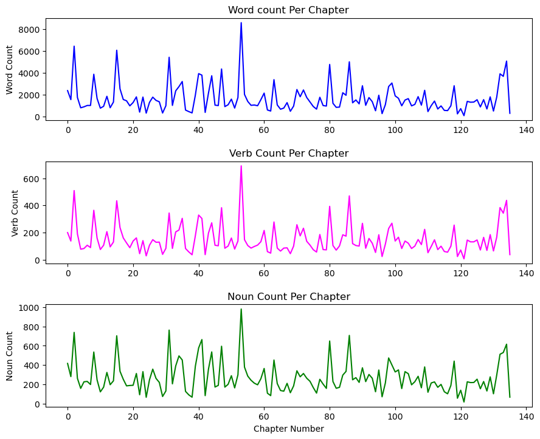

```python
import numpy as np
import matplotlib.pyplot as plt

fig = plt.figure(figsize = (10, 8))
plt.subplots_adjust(left=0.1,
                    bottom=0.1,
                    right=0.9,
                    top=0.9,
                    wspace=0.4,
                    hspace=0.4)
x = range(0,136)

plt.subplot(3, 1, 1)
plt.plot(x, wordscount, color ='blue')
#plt.xlabel('Chapter Number')
plt.ylabel('Word Count')
plt.title('Word count Per Chapter')

plt.subplot(3, 1, 2)

plt.plot(x, verbscount, color ='magenta')
#plt.xlabel('Chapter Number')
plt.ylabel('Verb Count')
plt.title('Verb Count Per Chapter')

plt.subplot(3, 1, 3)

plt.plot(x, nounscount, color ='green')
plt.xlabel('Chapter Number')
plt.ylabel('Noun Count')
plt.title('Noun Count Per Chapter')
plt.show()
```

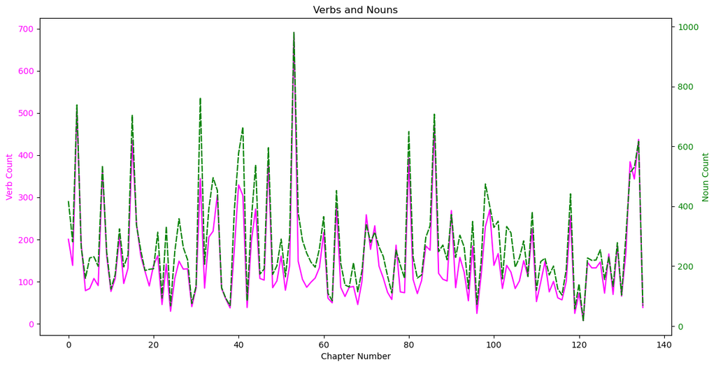

```python
fig, ax1 = plt.subplots(figsize = (12, 6))

color = 'tab:red'
ax1.set_xlabel('Chapter Number')
ax1.set_ylabel('Verb Count', color='magenta')
ax1.plot(x, verbscount, color='magenta')
ax1.tick_params(axis='y', labelcolor='magenta')

ax2 = ax1.twinx()  # instantiate a second axes that shares the same x-axis

color = 'tab:blue'
ax2.set_ylabel('Noun Count', color='green')  # we already handled the x-label with ax1
ax2.plot(x, nounscount, color='green', linestyle='--', dashes=(5,1))
ax2.tick_params(axis='y', labelcolor='green')

fig.tight_layout()  # otherwise the right y-label is slightly clipped
plt.title('Verbs and Nouns')
plt.show()
```

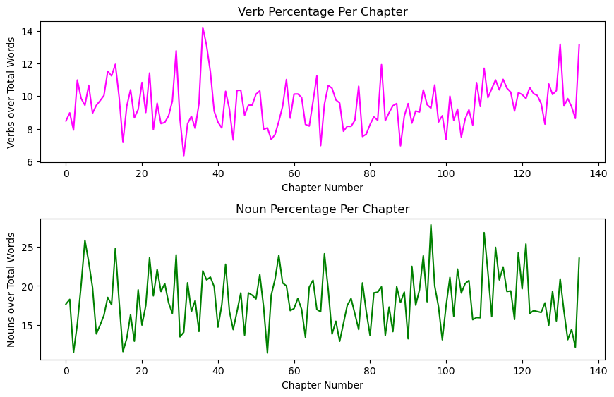

```python
fig = plt.figure(figsize = (10, 6))
plt.subplots_adjust(left=0.1,
                    bottom=0.1,
                    right=0.9,
                    top=0.9,
                    wspace=0.4,
                    hspace=0.4)



plt.subplot(2, 1, 1)
plt.plot(x, verbsPer, color ='magenta')
plt.xlabel('Chapter Number')
plt.ylabel('Verbs over Total Words')
plt.title('Verb Percentage Per Chapter')

plt.subplot(2, 1, 2)
plt.plot(x, nounsPer, color ='green')
plt.xlabel('Chapter Number')
plt.ylabel('Nouns over Total Words')
plt.title('Noun Percentage Per Chapter')
plt.show()
```

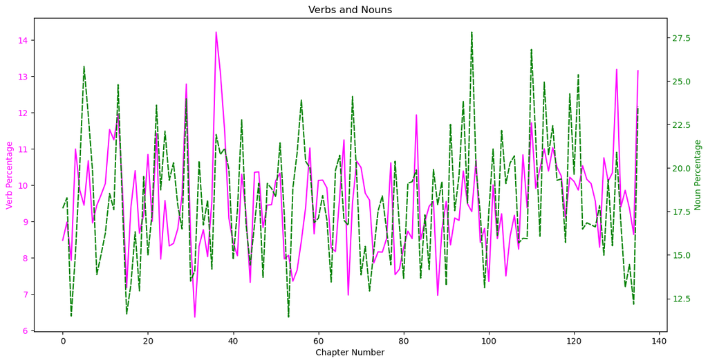

```python
fig, ax1 = plt.subplots(figsize = (12, 6))

color = 'tab:red'
ax1.set_xlabel('Chapter Number')
ax1.set_ylabel('Verb Percentage', color='magenta')
ax1.plot(x, verbsPer, color='magenta')
ax1.tick_params(axis='y', labelcolor='magenta')

ax2 = ax1.twinx()  # instantiate a second axes that shares the same x-axis

color = 'tab:blue'
ax2.set_ylabel('Noun Percentage', color='green')  # we already handled the x-label with ax1
ax2.plot(x, nounsPer, color='green', linestyle='--', dashes=(5,1))
ax2.tick_params(axis='y', labelcolor='green')

fig.tight_layout()  # otherwise the right y-label is slightly clipped
plt.title('Verbs and Nouns')
plt.show()
```

```python
print("filtering tokens...")
# build a list of sentences broken into tokens
# cull punctuation and digit tokens as they shouldn't factor in here.
texts: list[list[str]] = [
    [
        token.lemma_ for token in sentence.as_doc() if
        not token.is_stop
        and not token.is_punct
        and not token.is_digit
    ]
    for sentence in doc.sents
]


print("building dictionary and corpus...")
# build the dictionary based on our texts
id2word = corpora.Dictionary(texts)
# using the dictionary, convert string tokens into numerical tokens
corpus = [id2word.doc2bow(text) for text in texts]

print("instantiate the model and analyze the text...")
# instantiate the model object
lda_model = LdaModel(
    corpus=corpus,
    id2word=id2word,
    num_topics=20,
    random_state=100,
    update_every=1,
    chunksize=100,
    passes=10,
    alpha='auto',
    per_word_topics=True
)
# analyze the corpus
doc_lda = lda_model[corpus]
```

```
filtering tokens...
building dictionary and corpus...
instantiate the model and analyze the text...
```

```python
gensimvis.prepare(lda_model, corpus, id2word)
```

[interactive chart not shown]

# Analyzing topics of individual chapters

This is the same process as that for entire book text.\ \ The only difference is that we are iterating through the\ individual chapter texts and allowing spacy to process\ those.\ \ Additionally, we save these models to disk since they take a minute\ to prepare and we load them if they exist.

```python
models: list[LdaModel] = []
corpii: list[list[tuple[int, int]]] = []
gsdicts: list[corpora.Dictionary] = []

for chap_num, chap_text in dict_chapters.items():

    print(f"processing {chap_num}")
    # if the model exists on disk, just load that
    path_model_out: Path = path_models.joinpath(chap_num.replace(" ", "").replace(".", ""))
    if path_model_out.exists():
        with open(path_model_out.joinpath("model.pickle"), 'rb') as file:
            models.append(pickle.load(file))
        with open(path_model_out.joinpath("corpus.pickle"), 'rb') as file:
            corpii.append(pickle.load(file))
        with open(path_model_out.joinpath("gsdict.pickle"), 'rb') as file:
            gsdicts.append(pickle.load(file))
        continue

    doc = nlp(chap_text)

    texts: list[list[str]] = [
        [
            token.lemma_ for token in sentence.as_doc() if
            not token.is_stop
            and not token.is_punct
            and not token.is_digit
        ]
        for sentence in doc.sents
    ]
    id2word = corpora.Dictionary(texts)
    corpus = [id2word.doc2bow(text) for text in texts]
    lda_model = LdaModel(
        corpus=corpus,
        id2word=id2word,
        num_topics=20,
        random_state=100,
        update_every=1,
        chunksize=100,
        passes=10,
        alpha='auto',
        per_word_topics=True
    )
    doc_lda = lda_model[corpus]

    models.append(copy.copy(lda_model))
    corpii.append(copy.copy(corpus))
    gsdicts.append(copy.copy(id2word))
    pass
```

```
processing CHAPTER 1.
processing CHAPTER 2.
processing CHAPTER 3.
processing CHAPTER 4.
processing CHAPTER 5.
processing CHAPTER 6.
processing CHAPTER 7.
processing CHAPTER 8.
processing CHAPTER 9.
processing CHAPTER 10.
processing CHAPTER 11.
processing CHAPTER 12.
processing CHAPTER 13.
processing CHAPTER 14.
processing CHAPTER 15.
processing CHAPTER 16.
processing CHAPTER 17.
processing CHAPTER 18.
processing CHAPTER 19.
processing CHAPTER 20.
processing CHAPTER 21.
processing CHAPTER 22.
processing CHAPTER 23.
processing CHAPTER 24.
processing CHAPTER 25.
processing CHAPTER 26.
processing CHAPTER 27.
processing CHAPTER 28.
processing CHAPTER 29.
processing CHAPTER 30.
processing CHAPTER 31.
processing CHAPTER 32.
processing CHAPTER 33.
processing CHAPTER 34.
processing CHAPTER 35.
processing CHAPTER 36.
processing CHAPTER 37.
processing CHAPTER 38.
processing CHAPTER 39.
processing CHAPTER 40.
```

[output cut: 81 more lines]

```
processing CHAPTER 122.
processing CHAPTER 123.
processing CHAPTER 124.
processing CHAPTER 125.
processing CHAPTER 126.
processing CHAPTER 127.
processing CHAPTER 128.
processing CHAPTER 129.
processing CHAPTER 130.
processing CHAPTER 131.
processing CHAPTER 132.
processing CHAPTER 133.
processing CHAPTER 134.
processing CHAPTER 135.
processing Epilogue
```

# DUMP THE MODELS TO DISK IF WE ARE RE-EVALUATING

```python
# for i, chap in enumerate(dict_chapters.keys()):
#     path_chap: Path = path_models.joinpath(chap.replace(" ", "").replace(".", ""))
#     path_chap.mkdir(parents=True, exist_ok=True)
#     path_file_model: Path = path_chap.joinpath("model.pickle")
#     path_file_corpus: Path = path_chap.joinpath("corpus.pickle")
#     path_file_gsdict: Path = path_chap.joinpath("gsdict.pickle")
#     with open(path_file_model, 'wb') as file:
#         pickle.dump(models[i], file)
#     with open(path_file_corpus, 'wb') as file:
#         pickle.dump(corpii[i], file)
#     with open(path_file_gsdict, 'wb') as file:
#         pickle.dump(gsdicts[i], file)
```

```python
len(dict_chapters)
```

```
136
```

```python
index_chapter: int = 134
gensimvis.prepare(
    models[index_chapter],
    corpii[index_chapter],
    gsdicts[index_chapter]
)
```

[interactive chart not shown]

# Analysis and Discussion

### As a whole

We can see that overall the topics present in the text (discarding 's' as errata) are topped by 'whale' and 'man'. Based on prior knowledge (and some research), this seems to perfectly outline the fact that of the three (classical) types of story, those being man vs man, man vs self, and man vs nature this story seems to fall into the latter with the whale acting as nature and defying Ahab's (man's) plans.

Moving further down the list we can see the ship and sea make appearances which informs us that (along with whale) this is definitely a nautically themed tale.

Look, See, and Eye all appear near each other in the general list which is kind of interesting in a thematic sense. I would imagine a lot of the story is "beholding" something or other during the quest for the ultimate goal. It also could tell us something about the methods by which the narrator (and author) provide information to us the reader.

Of the spaced out topic groups, 1 (the upper right) doesn't seem to tell us much, though there is an empasis on 'eye' which we've discussed previously. 3 seems to focus heavily on the ship and the sea. And for 2 and the others in it's group they cover a range of topics. I find 6 to be particularly interesting as we may observe that 'captain' and 'mast' appear close to the top of the list which I would speculate is perhaps where he is often encountered.

### Per chapter

#### Chapter 1:

Topic 3 gives us some locations: 'nantucket' and 'new bedford' (though the latter is split) we can then surmise that the story at least begins in Massachusetts. We also see quite a lot of use of 'night' which I would guess means the story begins at night time. 'Doom' appears (not much) but is in interesting that it kind of foreshadows the ultimate conclusion of the book within the first chapter.

#### Chapter 64:

Immediately 'Whale' stands out quite a bit which makes me believe that the crew may have encountered the whale by this point in the story. 'Murderer', 'Cannibal', and 'Meat' appear in several of the topics which could indicate that potentially a crime was committed, though it could also just be discussion amongst the crew.

#### Chapter 133

Ahab seems to be a focus of the story near the end (which makes sense based on prior knowledge) as he appears in several of the topics fairly close to the top of the term list. Additionally, the whale makes an appearance again, as well as 'boat' which is interesting as it is explicitly different than 'ship' which has been liberally used up to this point. The use of a different term could indicate that the crew has switched vessels or at least temporarily are on a smaller craft. 'act' makes a definitive appearance among the lists of several topics which probably indicates that the action has picked up (probably the story's finale).